# Apartado 1

## 1. Vecinos Próximos

A continuación vamos a ejecutar un código que prueba la clasificación mediante vecinos próximos para 1,3,5,11,21 y 51 vecinos. Usaremos los ficheros "example1.data", "example2.data", "example3.data", "example4.data" y "wdbc.data".

Cabe destacar que solo lo probaremos con validación cruzada con 10 particiones, ya que es el tipo de partición más normal y si no tendríamos que hacer 90 ejecuciones para mostrar todos los casos.

Primero se probará con normalización y después sin normalizar.

### 1.1 Vecinos Próximos con normalización

```python
%%python3
from Datos import Datos
import EstrategiaParticionado
import Clasificador
import numpy as np

print("EJECUCION DEL ALGORITMO DE VECINOS PROXIMOS\n\n")
vecinos=[1,3,5,11,21,51]
ficheros=["example1","example2","example3","example4", "wdbc"]
for f in ficheros:
    for v in vecinos:
        print("EJECUCION DEL FICHERO "+f+" CON "+str(v)+" VECINOS:\n")
        data = 'ConjuntosDatos/'+f+'.data'
        dataset=Datos(data)
        estrategia= EstrategiaParticionado.ValidacionCruzada(10)
        clasificador=Clasificador.ClasificadorVecinosProximos(v,True)
        errores=clasificador.validacion(estrategia,dataset,clasificador,laplace=1, seed=None)
        print("Probabilidad de error: ",errores)
        media = np.mean(errores)
        d_tipica = np.std(np.transpose(np.array(errores)), axis=0)
        print("Promedio de error: ", media)
        print("Desviacion Tipica: ", d_tipica)
        print()
```

```
EJECUCION DEL ALGORITMO DE VECINOS PROXIMOS


EJECUCION DEL FICHERO example1 CON 1 VECINOS:

Probabilidad de error:  [0.275, 0.125, 0.1, 0.225, 0.2, 0.3, 0.15, 0.125, 0.175, 0.15]
Promedio de error:  0.1825
Desviacion Tipica:  0.0632949445059

EJECUCION DEL FICHERO example1 CON 3 VECINOS:

Probabilidad de error:  [0.1, 0.15, 0.175, 0.275, 0.125, 0.225, 0.225, 0.175, 0.1, 0.125]
Promedio de error:  0.1675
Desviacion Tipica:  0.055957573214

EJECUCION DEL FICHERO example1 CON 5 VECINOS:

Probabilidad de error:  [0.25, 0.05, 0.15, 0.2, 0.1, 0.15, 0.175, 0.175, 0.175, 0.15]
Promedio de error:  0.1575
Desviacion Tipica:  0.0512957113217

EJECUCION DEL FICHERO example1 CON 11 VECINOS:

Probabilidad de error:  [0.15, 0.05, 0.1, 0.175, 0.3, 0.1, 0.175, 0.15, 0.15, 0.125]
Promedio de error:  0.1475
Desviacion Tipica:  0.0626996810199

EJECUCION DEL FICHERO example1 CON 21 VECINOS:

Probabilidad de error:  [0.05, 0.1, 0.1, 0.2, 0.15, 0.05, 0.175, 0.175, 0.25, 0.075]
Promedio de error:  0.1325
Desviacion Tipica:  0.0642748006609

EJECUCION DEL FICHERO example1 CON 51 VECINOS:

Probabilidad de error:  [0.15, 0.125, 0.125, 0.15, 0.2, 0.15, 0.125, 0.15, 0.1, 0.175]
Promedio de error:  0.145
Desviacion Tipica:  0.0269258240357

EJECUCION DEL FICHERO example2 CON 1 VECINOS:
```

[output cut: 127 more lines]

```
Probabilidad de error:  [0.017857142857142856, 0.0, 0.017857142857142856, 0.03571428571428571, 0.03571428571428571, 0.03571428571428571, 0.03571428571428571, 0.017857142857142856, 0.03571428571428571, 0.09230769230769231]
Promedio de error:  0.0324450549451
Desviacion Tipica:  0.0230826294619

EJECUCION DEL FICHERO wdbc CON 21 VECINOS:

Probabilidad de error:  [0.03571428571428571, 0.10714285714285714, 0.07142857142857142, 0.0, 0.07142857142857142, 0.0, 0.05357142857142857, 0.03571428571428571, 0.05357142857142857, 0.03076923076923077]
Promedio de error:  0.0459340659341
Desviacion Tipica:  0.0313398328421

EJECUCION DEL FICHERO wdbc CON 51 VECINOS:

Probabilidad de error:  [0.03571428571428571, 0.0, 0.08928571428571429, 0.03571428571428571, 0.05357142857142857, 0.07142857142857142, 0.03571428571428571, 0.03571428571428571, 0.03571428571428571, 0.06153846153846154]
Promedio de error:  0.0454395604396
Desviacion Tipica:  0.0233685136253
```

Para el fichero "example1.data" podemos observar que el promedio de error varía entre 0.10 y 0.20 para los k(de ahora en adelante k se referirá a 1,3,5,11,21 y 51 vecinos) vecinos, es un valor alto debido a que el example1 tiene una composión de datos muy mala. Por último añadir que la desviación típica es muy baja. Para el fichero "example2.data" el promedio de error y la desviación típica para K vecinos es de 0 por lo que lo clasifica a la perfección esto es debido a que los datos son muy homogéneos y solo hay dos tipos de datos '+' y '-'. Para el fichero "example3.data" el promedio de error es muy bajo entre 0 y 0.125 para k vecinos y con una desviación típica muy baja. Esto es debido a que es un fichero de datos que nuestro clasificador clasifica muy bien por su composición. Para el fichero "example4.data" el promedio de error y la desviación típica para k vecinos es de 0 por lo que clasifica a la perfección y aunque este fichero de datos es más heterogéneo que "example2.data" los datos varían en un rango muy bajo (de -0.2 a 0.2) y el calsificador predice perfectamente los diferentes casos. Para el fichero "wdbc.data" el promedio de error varía entre 0.05 y 0.03 aproximadamente para k vecinos y la desviación típica se mantiene muy baja por lo que esta probabilidad de error a penas varía. Este es un resultado muy bueno para nuestro clasificador ya que el fichero de datos es más heterogeneo que los anteriores y con un número de datos mucho más elevado, cabe destacar que es un fichero de datos real y el resultado es muy satisfacctorio. Estos datos serán contrastados más tarde con los resultados obtenidos por el clasificador de vecinos próximos implementado con Scikit.

### 1.2 Vecinos Próximos sin normalización

```python
%%python3
from Datos import Datos
import EstrategiaParticionado
import Clasificador
import numpy as np

print("EJECUCION DEL ALGORITMO DE VECINOS PROXIMOS\n\n")
vecinos=[1,3,5,11,21,51]
ficheros=["example1","example2","example3","example4", "wdbc"]
for f in ficheros:
    for v in vecinos:
        print("EJECUCION DEL FICHERO "+f+" CON "+str(v)+" VECINOS:\n")
        data = 'ConjuntosDatos/'+f+'.data'
        dataset=Datos(data)
        estrategia= EstrategiaParticionado.ValidacionCruzada(10)
        clasificador=Clasificador.ClasificadorVecinosProximos(v,False)
        errores=clasificador.validacion(estrategia,dataset,clasificador,laplace=1, seed=None)
        print("Probabilidad de error: ",errores)
        media = np.mean(errores)
        d_tipica = np.std(np.transpose(np.array(errores)), axis=0)
        print("Promedio de error: ", media)
        print("Desviacion Tipica: ", d_tipica)
        print()
```

```
EJECUCION DEL ALGORITMO DE VECINOS PROXIMOS


EJECUCION DEL FICHERO example1 CON 1 VECINOS:

Probabilidad de error:  [0.275, 0.325, 0.25, 0.175, 0.125, 0.175, 0.2, 0.1, 0.125, 0.15]
Promedio de error:  0.19
Desviacion Tipica:  0.0691013748054

EJECUCION DEL FICHERO example1 CON 3 VECINOS:

Probabilidad de error:  [0.2, 0.225, 0.125, 0.175, 0.1, 0.2, 0.2, 0.225, 0.1, 0.05]
Promedio de error:  0.16
Desviacion Tipica:  0.0583095189485

EJECUCION DEL FICHERO example1 CON 5 VECINOS:

Probabilidad de error:  [0.1, 0.2, 0.225, 0.1, 0.175, 0.275, 0.1, 0.175, 0.125, 0.175]
Promedio de error:  0.165
Desviacion Tipica:  0.0561248608016

EJECUCION DEL FICHERO example1 CON 11 VECINOS:

Probabilidad de error:  [0.125, 0.15, 0.125, 0.15, 0.2, 0.15, 0.075, 0.075, 0.1, 0.1]
Promedio de error:  0.125
Desviacion Tipica:  0.0370809924355

EJECUCION DEL FICHERO example1 CON 21 VECINOS:

Probabilidad de error:  [0.125, 0.125, 0.075, 0.225, 0.175, 0.1, 0.1, 0.15, 0.1, 0.125]
Promedio de error:  0.13
Desviacion Tipica:  0.0415331193146

EJECUCION DEL FICHERO example1 CON 51 VECINOS:

Probabilidad de error:  [0.15, 0.1, 0.2, 0.125, 0.1, 0.2, 0.1, 0.2, 0.15, 0.05]
Promedio de error:  0.1375
Desviacion Tipica:  0.0490535421759

EJECUCION DEL FICHERO example2 CON 1 VECINOS:
```

[output cut: 127 more lines]

```
Probabilidad de error:  [0.017857142857142856, 0.03571428571428571, 0.07142857142857142, 0.03571428571428571, 0.017857142857142856, 0.0, 0.017857142857142856, 0.03571428571428571, 0.03571428571428571, 0.03076923076923077]
Promedio de error:  0.0298626373626
Desviacion Tipica:  0.0178596997324

EJECUCION DEL FICHERO wdbc CON 21 VECINOS:

Probabilidad de error:  [0.017857142857142856, 0.05357142857142857, 0.05357142857142857, 0.0, 0.07142857142857142, 0.03571428571428571, 0.05357142857142857, 0.03571428571428571, 0.017857142857142856, 0.07692307692307693]
Promedio de error:  0.0416208791209
Desviacion Tipica:  0.0234407640222

EJECUCION DEL FICHERO wdbc CON 51 VECINOS:

Probabilidad de error:  [0.03571428571428571, 0.03571428571428571, 0.07142857142857142, 0.05357142857142857, 0.03571428571428571, 0.05357142857142857, 0.017857142857142856, 0.08928571428571429, 0.03571428571428571, 0.06153846153846154]
Promedio de error:  0.049010989011
Desviacion Tipica:  0.0200022640911
```

En general los resultados obtenidos por el algoritmo de clasificación de Vecinos Próximos con normalización es bastante parecido al resultado obtenido por el algoritmo de clasificación de Vecinos Próximos sin normalización. En general este último es en ocasiones más elevado que elresultado normalizado.

Para el fichero "example2.data" el promedio de error y la desviación típica para K vecinos es de 0 por lo que lo clasifica a la perfección esto es debido a que los datos son muy homogéneos y solo hay dos tipos de datos '+' y '-'. En comparación con el resultado obtenido con la normalización es igual.

Para el fichero "example3.data" el promedio de error es muy bajo entre 0 y 0.125 para k vecinos y con una desviación típica muy baja. Esto es debido a que es un fichero de datos que nuestro clasificador clasifica muy bien por su composición. En comparación con el resultado obtenido con la normalización es bastante similar, solo en un único caso ha salido mayor en el caso normalizado.

Para el fichero "example4.data" el promedio de error y la desviación típica para k vecinos es de 0 por lo que clasifica a la perfección y aunque este fichero de datos es más heterogéneo que "example2.data" los datos varían en un rango muy bajo (de -0.2 a 0.2) y el calsificador predice perfectamente los diferentes casos. En comparación con el resultado obtenido con la normalización es igual.

Para el fichero "wdbc.data" el promedio de error varía entre 0.05 y 0.03 aproximadamente para k vecinos y la desviación típica se mantiene muy baja por lo que esta probabilidad de error a penas varía. Este es un resultado muy bueno para nuestro clasificador ya que el fichero de datos es más heterogeneo que los anteriores y con un número de datos mucho más elevado, cabe destacar que es un fichero de datos real y el resultado es muy satisfacctorio. En comparación con el resultado obtenido con la normalización como en el caso con "example3.data" es muy similar y a penas varía.

Podemos concluir que la normalización con Vecinos próximos en estos ficheros no es muy diferente, pero siempre es recomendable, ya que nos podemos encontrar con otros ficheros que mezclen, por ejemplo, unidades de medida y será necesario normalizar para obtener resultados fiables.

Estos datos serán contrastados más tarde con los resultados obtenidos por el clasificador de vecinos próximos implementado con Scikit.

## Apartado 2

A continuación vamos a ejecutar un código que prueba la clasificación mediante regresión logística con 100 épocas. Usaremos los ficheros "example1.data", "example2.data", "example3.data", "example4.data" y "wdbc.data".

Cabe destacar que solo lo probaremos con validación cruzada con 10 particiones, ya que es el tipo de partición más normal y si no tendríamos que hacer numerosas ejecuciones para mostrar todos los casos.

Primero se usará con normalización y después sin normalizar.

### 2.1 Regresión logística con normalización

```python
%%python3
from Datos import Datos
import EstrategiaParticionado
import Clasificador
import numpy as np

print("EJECUCION DEL ALGORITMO DE REGRESION LOGISTICA\n\n")
ficheros=["example1","example2","example3","example4", "wdbc"]
for f in ficheros:
    print("EJECUCION DEL FICHERO "+f+"\n")
    data = 'ConjuntosDatos/'+f+'.data'
    dataset=Datos(data)
    estrategia= EstrategiaParticionado.ValidacionCruzada(10)
    clasificador=Clasificador.ClasificadorRegresionLogistica(100,1,True)
    errores=clasificador.validacion(estrategia,dataset,clasificador,laplace=1, seed=None)
    print("Probabilidad de error: ",errores)
    media = np.mean(errores)
    d_tipica = np.std(np.transpose(np.array(errores)), axis=0)
    print("Promedio de error: ", media)
    print("Desviacion Tipica: ", d_tipica)
    print()
```

```
EJECUCION DEL ALGORITMO DE REGRESION LOGISTICA


EJECUCION DEL FICHERO example1

Probabilidad de error:  [0.525, 0.45, 0.475, 0.575, 0.425, 0.575, 0.575, 0.5, 0.375, 0.525]
Promedio de error:  0.5
Desviacion Tipica:  0.065192024052

EJECUCION DEL FICHERO example2

Probabilidad de error:  [0.225, 0.3, 0.3, 0.225, 0.275, 0.25, 0.225, 0.2, 0.475, 0.525]
Promedio de error:  0.3
Desviacion Tipica:  0.105475115549

EJECUCION DEL FICHERO example3

Probabilidad de error:  [0.375, 0.4, 0.425, 0.55, 0.25, 0.375, 0.45, 0.375, 0.425, 0.625]
Promedio de error:  0.425
Desviacion Tipica:  0.0974679434481

EJECUCION DEL FICHERO example4

Probabilidad de error:  [0.6, 0.3, 0.6, 0.4, 0.8, 0.4, 0.4, 0.6, 0.5, 0.4]
Promedio de error:  0.5
Desviacion Tipica:  0.141421356237

EJECUCION DEL FICHERO wdbc

Probabilidad de error:  [0.26785714285714285, 0.32142857142857145, 0.375, 0.48214285714285715, 0.35714285714285715, 0.21428571428571427, 0.25, 0.10714285714285714, 0.14285714285714285, 0.13846153846153847]
Promedio de error:  0.265631868132
Desviacion Tipica:  0.113831611173
```

Para el fichero "example1.data" podemos observar que el promedio de error varía entre 0.375 y 0.525 aproximadamente, es un valor alto debido a que el example1 tiene una composión de datos muy mala. Por último añadir que la desviación típica es muy baja.

Para el fichero "example2.data" el promedio de error es de 0.2 a a 0.5, es un valor alto debido a que el example2 tiene una composición de datos mala. Por último añadir que la desviación típica es baja de 0.1 y esto puede hacer que los datos varien.

Para el fichero "example3.data" el promedio de error es alto entre 0.25 y 0.625 y con una desviación típica muy baja. Esto es debido a que es un fichero de datos muy heterogéneo y con una composición de datos mala.

Para el fichero "wdbc.data" el promedio de error varía entre 0.10 y 0.5 aproximadamente y la desviación típica se mantiene baja con 0.11 por lo que esta probabilidad de error puede varíar. Este es un resultado no muy bueno para nuestro clasificador. Esto puede ser debido a que el fichero de datos es más heterogeneo que los anteriores y con un número de datos mucho más elevado, cabe destacar que es un fichero de datos real y el resultado no es satisfacctorio.

En comparación con la clasificación de estos ficheros por el algoritmo de vecinos próximos los resultados son bastante peores, esto muestra que el algoritmo de vecinos próximos clasifica mejor este tipo de ficheros y datos.

Estos datos serán contrastados más tarde con los resultados obtenidos por el clasificador de regresión logística de Scikit.

### 2.2 Regresión logística sin normalización

```python
%%python3
from Datos import Datos
import EstrategiaParticionado
import Clasificador
import numpy as np

print("EJECUCION DEL ALGORITMO DE REGRESION LOGISTICA\n\n")
ficheros=["example1","example2","example3","example4", "wdbc"]
for f in ficheros:
    print("EJECUCION DEL FICHERO "+f+"\n")
    data = 'ConjuntosDatos/'+f+'.data'
    dataset=Datos(data)
    estrategia= EstrategiaParticionado.ValidacionCruzada(10)
    clasificador=Clasificador.ClasificadorRegresionLogistica(100,1,False)
    errores=clasificador.validacion(estrategia,dataset,clasificador,laplace=1, seed=None)
    print("Probabilidad de error: ",errores)
    media = np.mean(errores)
    d_tipica = np.std(np.transpose(np.array(errores)), axis=0)
    print("Promedio de error: ", media)
    print("Desviacion Tipica: ", d_tipica)
    print()
```

```
EJECUCION DEL ALGORITMO DE REGRESION LOGISTICA


EJECUCION DEL FICHERO example1

Probabilidad de error:  [0.525, 0.4, 0.425, 0.575, 0.65, 0.425, 0.6, 0.55, 0.575, 0.725]
Promedio de error:  0.545
Desviacion Tipica:  0.0992471662064

EJECUCION DEL FICHERO example2

Probabilidad de error:  [0.525, 0.4, 0.45, 0.525, 0.575, 0.5, 0.575, 0.4, 0.575, 0.525]
Promedio de error:  0.505
Desviacion Tipica:  0.0640312423743

EJECUCION DEL FICHERO example3

Probabilidad de error:  [0.425, 0.375, 0.25, 0.35, 0.425, 0.425, 0.45, 0.4, 0.325, 0.6]
Promedio de error:  0.4025
Desviacion Tipica:  0.0869266932536

EJECUCION DEL FICHERO example4

Probabilidad de error:  [0.6, 0.5, 0.5, 0.5, 0.5, 0.6, 0.4, 0.5, 0.3, 0.6]
Promedio de error:  0.5
Desviacion Tipica:  0.0894427191

EJECUCION DEL FICHERO wdbc

Probabilidad de error:  [0.08928571428571429, 0.26785714285714285, 0.10714285714285714, 0.125, 0.17857142857142858, 0.30357142857142855, 0.21428571428571427, 0.07142857142857142, 0.2857142857142857, 0.24615384615384617]
Promedio de error:  0.188901098901
Desviacion Tipica:  0.0820218705463
```

Para el fichero "example1.data" podemos observar que el promedio de error varía entre 0.425 y 0.725 aproximadamente, es un valor alto debido a que el example1 tiene una composión de datos muy mala. Por último añadir que la desviación típica es muy baja. En comparación con la regresión logística normalizada el promedio de error aumenta.

Para el fichero "example3.data" el promedio de error es alto entre 0.25 y 0.625 y con una desviación típica muy baja. Esto es debido a que es un fichero de datos muy heterogéneo y con una composición de datos mala. En comparación con regresión logística normalizada el promedio de error no varía demasiado.

En comparación con la clasificación de estos ficheros por el algoritmo de vecinos próximos los resultados son bastante peores, esto muestra que el algoritmo de vecinos próximos clasifica mejor este tipo de ficheros y datos.

Estos datos serán contrastados más tarde con los resultados obtenidos por el clasificador de regresión logística de Scikit.

## 2.3 Regresión Logistica variando épocas y constante de apredizaje

```python
%%python3
from Datos import Datos
import EstrategiaParticionado
import Clasificador
import numpy as np

print("EJECUCION DEL ALGORITMO DE REGRESION LOGISTICA\n\n")
ficheros=["example1","example2","example3","example4", "wdbc"]
constante=[1, 0.5, 0.3]
epocas=[100,500,1000]
for f in ficheros:
    for e in epocas:
        for c in constante:
            print("EJECUCION DEL FICHERO "+f+" CON CTE. APRENDIZAJE "+str(c)+ "Y N.EPOCAS "+str(e)+"\n")
            data = 'ConjuntosDatos/'+f+'.data'
            dataset=Datos(data)
            estrategia= EstrategiaParticionado.ValidacionCruzada(10)
            clasificador=Clasificador.ClasificadorRegresionLogistica(e,c,True)
            errores=clasificador.validacion(estrategia,dataset,clasificador,laplace=1, seed=None)
            print("Probabilidad de error: ",errores)
            media = np.mean(errores)
            d_tipica = np.std(np.transpose(np.array(errores)), axis=0)
            print("Promedio de error: ", media)
            print("Desviacion Tipica: ", d_tipica)
            print()
```

```
EJECUCION DEL ALGORITMO DE REGRESION LOGISTICA


EJECUCION DEL FICHERO example1 CON CTE. APRENDIZAJE 1Y N.EPOCAS 100

Probabilidad de error:  [0.525, 0.35, 0.525, 0.525, 0.35, 0.525, 0.475, 0.525, 0.35, 0.475]
Promedio de error:  0.4625
Desviacion Tipica:  0.0760345316287

EJECUCION DEL FICHERO example1 CON CTE. APRENDIZAJE 0.5Y N.EPOCAS 100

Probabilidad de error:  [0.625, 0.525, 0.475, 0.6, 0.625, 0.575, 0.725, 0.625, 0.475, 0.725]
Promedio de error:  0.5975
Desviacion Tipica:  0.0840014880821

EJECUCION DEL FICHERO example1 CON CTE. APRENDIZAJE 0.3Y N.EPOCAS 100

Probabilidad de error:  [0.575, 0.75, 0.55, 0.5, 0.525, 0.65, 0.525, 0.75, 0.575, 0.475]
Promedio de error:  0.5875
Desviacion Tipica:  0.0930389703296

EJECUCION DEL FICHERO example1 CON CTE. APRENDIZAJE 1Y N.EPOCAS 500

Probabilidad de error:  [0.425, 0.425, 0.5, 0.5, 0.35, 0.5, 0.45, 0.625, 0.575, 0.65]
Promedio de error:  0.5
Desviacion Tipica:  0.0894427191

EJECUCION DEL FICHERO example1 CON CTE. APRENDIZAJE 0.5Y N.EPOCAS 500

Probabilidad de error:  [0.475, 0.675, 0.7, 0.575, 0.575, 0.45, 0.425, 0.55, 0.625, 0.6]
Promedio de error:  0.565
Desviacion Tipica:  0.0874642784227

EJECUCION DEL FICHERO example1 CON CTE. APRENDIZAJE 0.3Y N.EPOCAS 500

Probabilidad de error:  [0.4, 0.35, 0.4, 0.7, 0.6, 0.575, 0.55, 0.6, 0.525, 0.525]
Promedio de error:  0.5225
Desviacion Tipica:  0.103350133043

EJECUCION DEL FICHERO example1 CON CTE. APRENDIZAJE 1Y N.EPOCAS 1000
```

[output cut: 217 more lines]

```
Probabilidad de error:  [0.16071428571428573, 0.32142857142857145, 0.10714285714285714, 0.19642857142857142, 0.16071428571428573, 0.08928571428571429, 0.10714285714285714, 0.08928571428571429, 0.19642857142857142, 0.26153846153846155]
Promedio de error:  0.169010989011
Desviacion Tipica:  0.0733492611868

EJECUCION DEL FICHERO wdbc CON CTE. APRENDIZAJE 0.5Y N.EPOCAS 1000

Probabilidad de error:  [0.25, 0.35714285714285715, 0.39285714285714285, 0.42857142857142855, 0.375, 0.44642857142857145, 0.2857142857142857, 0.23214285714285715, 0.30357142857142855, 0.2]
Promedio de error:  0.327142857143
Desviacion Tipica:  0.080894236822

EJECUCION DEL FICHERO wdbc CON CTE. APRENDIZAJE 0.3Y N.EPOCAS 1000

Probabilidad de error:  [0.19642857142857142, 0.26785714285714285, 0.32142857142857145, 0.25, 0.2857142857142857, 0.4107142857142857, 0.17857142857142858, 0.32142857142857145, 0.19642857142857142, 0.4307692307692308]
Promedio de error:  0.285934065934
Desviacion Tipica:  0.0826040747194
```

Para simplificar la explicación de como varían los resultados conforme varían el numero de épocas y la constante de aprendizaje solo nos vamos a fijar en el promedio de error para cada fichero.

Para el fichero "example1.data" podemos observar que la variación del número de épocas no ha hecho que el resultado promedio varíe demasiado, en cambio, podemos comprobar que si disminuimos la constante de aprendizaje el promedio de error aumenta.

Para el fichero "example2.data" podemos observar que la variación del número de épocas no ha hecho que el resultado promedio varíe demasiado en algun caso al aumentar la probabilidad de error a aumentado pero puede ser por la aleatoriedad de los datos, en cambio, podemos comprobar que si disminuimos la constante de aprendizaje el promedio de error aumenta ligeramente.

Para el fichero "example3.data" podemos observar que la variación del número de épocas no ha hecho que el resultado promedio varíe demasiado, en cambio, podemos comprobar que si disminuimos la constante de aprendizaje el promedio de error disminuye a diferencia del resto, esto puede ser debido a la composición de datos del fichero.

Para el fichero "example4.data" podemos observar que la variación del número de épocas y la variación de la constante de aprendizaje no han hecho que el promedio de error varíe, siendo este 0.5, el cual es bastante alto.

Para el fichero "wdbc.data" podemos observar que la variación del número de épocas ha hecho que el resultado promedio disminuya, en cambio, podemos comprobar que en ciertos casos si disminuimos la constante de aprendizaje el promedio de error disminuye y en otros aumenta.

Podemos observar que los datos no difieren mucho de los obtenidos anteriormente con el algoritmo de regresión logística con datos normalizados como es obvio, en cambio si podemos apreciar los cambios que realizan el número de épocas en el algoritmo y la constante de aprendizaje.

# Apartado 3

En este apartado primero vamos a mostrar los resultados de los algoritmos de vecinos próximos con k 1,3,5,11,21,51 y regresión logística, aunque en ambos casos hay opción de normalizar por simplificar vamos a ejecutarlo con normalización y validación cruzada de 10 particiones. Posteriormente vamos a comparar los resultados obtenidos por Scikit con los resultados obtenidos por los clasificadores implementados por nosotros para los ficheros "example1.data", "example2.data", "example3.data", "example4.data" y "wdbc.data".

La segunda parte de este apartado va a mostrar las nubes de puntos y fronteras obtenidas por los dos algoritmos de clasificación para los ficheros "example1.data", "example2.data", "example3.data" y "example4.data".

## 3.1 Vecinos Próximos con Scikit Learn

```python
%%python3
from ClasificadorScikit import VecinosProximos
import EstrategiaParticionado
import numpy as np

ficheros=["example1","example2","example3","example4", "wdbc"]
vecinos=[1,3,5,11,21,51]
for f in ficheros:
    for v in vecinos:
        print("EJECUCION DEL FICHERO "+f+" CON "+str(v)+" VECINOS:\n")
        data = 'ConjuntosDatos/'+f+'.data'
        estrategia= EstrategiaParticionado.ValidacionCruzada(10)
        errores = VecinosProximos(data, v, estrategia, True)
        print(errores)
        media = np.mean(errores)
        d_tipica = np.std(np.transpose(np.array(errores)), axis=0)
        print("Promedio de error: ", media)
        print("Desviacion Tipica: ", d_tipica)
        print()
```

```
EJECUCION DEL FICHERO example1 CON 1 VECINOS:

[0.074999999999999956, 0.125, 0.30000000000000004, 0.15000000000000002, 0.15000000000000002, 0.125, 0.30000000000000004, 0.22499999999999998, 0.125, 0.074999999999999956]
Promedio de error:  0.165
Desviacion Tipica:  0.0784219357068

EJECUCION DEL FICHERO example1 CON 3 VECINOS:

[0.025000000000000022, 0.17500000000000004, 0.15000000000000002, 0.17500000000000004, 0.15000000000000002, 0.19999999999999996, 0.15000000000000002, 0.17500000000000004, 0.125, 0.074999999999999956]
Promedio de error:  0.14
Desviacion Tipica:  0.0502493781056

EJECUCION DEL FICHERO example1 CON 5 VECINOS:

[0.074999999999999956, 0.17500000000000004, 0.15000000000000002, 0.125, 0.125, 0.125, 0.19999999999999996, 0.19999999999999996, 0.15000000000000002, 0.050000000000000044]
Promedio de error:  0.1375
Desviacion Tipica:  0.0464354390525

EJECUCION DEL FICHERO example1 CON 11 VECINOS:

[0.074999999999999956, 0.15000000000000002, 0.15000000000000002, 0.099999999999999978, 0.125, 0.099999999999999978, 0.17500000000000004, 0.17500000000000004, 0.17500000000000004, 0.050000000000000044]
Promedio de error:  0.1275
Desviacion Tipica:  0.0425

EJECUCION DEL FICHERO example1 CON 21 VECINOS:

[0.125, 0.19999999999999996, 0.15000000000000002, 0.099999999999999978, 0.125, 0.074999999999999956, 0.125, 0.19999999999999996, 0.19999999999999996, 0.125]
Promedio de error:  0.1425
Desviacion Tipica:  0.0419076365356

EJECUCION DEL FICHERO example1 CON 51 VECINOS:

[0.050000000000000044, 0.19999999999999996, 0.125, 0.125, 0.15000000000000002, 0.074999999999999956, 0.125, 0.125, 0.15000000000000002, 0.099999999999999978]
Promedio de error:  0.1225
Desviacion Tipica:  0.0394493345951

EJECUCION DEL FICHERO example2 CON 1 VECINOS:

[0.0, 0.0, 0.0, 0.0, 0.0, 0.0, 0.0, 0.0, 0.0, 0.0]
Promedio de error:  0.0
```

[output cut: 124 more lines]

```
[0.035714285714285698, 0.1071428571428571, 0.053571428571428603, 0.071428571428571397, 0.1428571428571429, 0.053571428571428603, 0.071428571428571397, 0.035714285714285698, 0.035714285714285698, 0.092307692307692313]
Promedio de error:  0.0699450549451
Desviacion Tipica:  0.0335496143224

EJECUCION DEL FICHERO wdbc CON 21 VECINOS:

[0.035714285714285698, 0.125, 0.053571428571428603, 0.053571428571428603, 0.125, 0.053571428571428603, 0.053571428571428603, 0.053571428571428603, 0.035714285714285698, 0.092307692307692313]
Promedio de error:  0.0681593406593
Desviacion Tipica:  0.0319597607502

EJECUCION DEL FICHERO wdbc CON 51 VECINOS:

[0.071428571428571397, 0.125, 0.053571428571428603, 0.071428571428571397, 0.1607142857142857, 0.071428571428571397, 0.071428571428571397, 0.053571428571428603, 0.035714285714285698, 0.15384615384615385]
Promedio de error:  0.0868131868132
Desviacion Tipica:  0.0414498444232
```

El promedio de error del fichero "example1.data" es muy bajo varía muy poco al aumentar el número de vecinos disminuyendo normalmente. El resultado es menor al obtenido con nuestro clasificador por lo que en este caso scikit clasifica mejor.

El promedio de error del fichero "example2.data" es nulo para todos los vecinos. El resultado es igual al de nuestro clasificador.

El promedio de error del fichero "example3.data" es muy bajo varía muy poco al aumentar el número de vecinos disminuyendo normalmente. El resultado es muy similar al obtenido con nuestro clasificador, por lo que ambos clasificadores clasifican bien ya que el promedio de error es muy bajo.

El promedio de error del fichero "example4.data" es muy bajo y en este caso aumenta al aumentar el número de vecinos. El resultado es diferente al obtenido con nuestro clasificador, ya que nuestro clasificador en este fichero acierta todos siempre y el promedio de error es 0, por lo que nuestro clasificador clasifica mucho mejor este fichero.

El promedio de error del fichero "wdbc.data"es muy bajo varía muy poco al aumentar el número de vecinos aumenta el promedio de error. El resultado es muy un poco mayor al obtenido con nuestro clasificador, por lo que nuestro clasificador clasifica mejor con mayor número de vecinos.

Podemos determinar que nuestro clasificador clasifica mejor que las funciones implementadas por Scikit, esto puede ser debido a que nuestro algoritmo lo hace todo paso a paso usando los principios matemáticos usados en teoría por lo que puede ser más preciso. Otra opción también puede ser que no hayamos sabido ajustar el clasificador de vecinos próximos de Scikit Learn para que sea mucho más preciso.

## 3.2 Regresión Logística con Scikit Learn

```python
%%python3
from ClasificadorScikit import RegresionLogistica
import EstrategiaParticionado
import numpy as np

ficheros=["example1","example2","example3","example4", "wdbc"]
constante=[1, 0.5, 0.3]
epocas=[100,500,1000]

for f in ficheros:
    for e in epocas:
        for c in constante:
            data = 'ConjuntosDatos/'+f+'.data'
            print("EJECUCION DEL FICHERO "+f+" CON CTE. APRENDIZAJE "+str(c)+ "Y N.EPOCAS "+str(e)+"\n")
            estrategia= EstrategiaParticionado.ValidacionCruzada(10)
            errores = RegresionLogistica(data, e, estrategia, c)
            print(errores)
            media = np.mean(errores)
            d_tipica = np.std(np.transpose(np.array(errores)), axis=0)
            print("Promedio de error: ", media)
            print("Desviacion Tipica: ", d_tipica)
            print()
```

```
EJECUCION DEL FICHERO example1 CON CTE. APRENDIZAJE 1Y N.EPOCAS 100

[0.5, 0.47499999999999998, 0.57499999999999996, 0.52500000000000002, 0.52500000000000002, 0.55000000000000004, 0.5, 0.22499999999999998, 0.55000000000000004, 0.55000000000000004]
Promedio de error:  0.4975
Desviacion Tipica:  0.0951643315534

EJECUCION DEL FICHERO example1 CON CTE. APRENDIZAJE 0.5Y N.EPOCAS 100

[0.625, 0.57499999999999996, 0.625, 0.42500000000000004, 0.57499999999999996, 0.52500000000000002, 0.44999999999999996, 0.57499999999999996, 0.55000000000000004, 0.59999999999999998]
Promedio de error:  0.5525
Desviacion Tipica:  0.0646625857819

EJECUCION DEL FICHERO example1 CON CTE. APRENDIZAJE 0.3Y N.EPOCAS 100

[0.55000000000000004, 0.59999999999999998, 0.67500000000000004, 0.69999999999999996, 0.67500000000000004, 0.5, 0.69999999999999996, 0.72499999999999998, 0.44999999999999996, 0.52500000000000002]
Promedio de error:  0.61
Desviacion Tipica:  0.0930053761887

EJECUCION DEL FICHERO example1 CON CTE. APRENDIZAJE 1Y N.EPOCAS 500

[0.55000000000000004, 0.52500000000000002, 0.55000000000000004, 0.625, 0.65000000000000002, 0.75, 0.55000000000000004, 0.52500000000000002, 0.47499999999999998, 0.52500000000000002]
Promedio de error:  0.5725
Desviacion Tipica:  0.0761987532706

EJECUCION DEL FICHERO example1 CON CTE. APRENDIZAJE 0.5Y N.EPOCAS 500

[0.55000000000000004, 0.52500000000000002, 0.52500000000000002, 0.52500000000000002, 0.625, 0.57499999999999996, 0.72499999999999998, 0.59999999999999998, 0.625, 0.375]
Promedio de error:  0.565
Desviacion Tipica:  0.0867467578645

EJECUCION DEL FICHERO example1 CON CTE. APRENDIZAJE 0.3Y N.EPOCAS 500

[0.55000000000000004, 0.75, 0.59999999999999998, 0.57499999999999996, 0.65000000000000002, 0.57499999999999996, 0.47499999999999998, 0.75, 0.55000000000000004, 0.65000000000000002]
Promedio de error:  0.6125
Desviacion Tipica:  0.0838525491562

EJECUCION DEL FICHERO example1 CON CTE. APRENDIZAJE 1Y N.EPOCAS 1000

[0.55000000000000004, 0.47499999999999998, 0.52500000000000002, 0.47499999999999998, 0.57499999999999996, 0.59999999999999998, 0.52500000000000002, 0.57499999999999996, 0.5, 0.5]
Promedio de error:  0.53
```

[output cut: 214 more lines]

```
[0.071428571428571397, 0.053571428571428603, 0.125, 0.071428571428571397, 0.125, 0.089285714285714302, 0.053571428571428603, 0.1071428571428571, 0.089285714285714302, 0.046153846153846101]
Promedio de error:  0.0831868131868
Desviacion Tipica:  0.0274719230703

EJECUCION DEL FICHERO wdbc CON CTE. APRENDIZAJE 0.5Y N.EPOCAS 1000

[0.071428571428571397, 0.1607142857142857, 0.035714285714285698, 0.1071428571428571, 0.071428571428571397, 0.071428571428571397, 0.1071428571428571, 0.089285714285714302, 0.089285714285714302, 0.030769230769230771]
Promedio de error:  0.0834340659341
Desviacion Tipica:  0.0355641497711

EJECUCION DEL FICHERO wdbc CON CTE. APRENDIZAJE 0.3Y N.EPOCAS 1000

[0.1071428571428571, 0.125, 0.2142857142857143, 0.089285714285714302, 0.125, 0.089285714285714302, 0.125, 0.089285714285714302, 0.053571428571428603, 0.076923076923076872]
Promedio de error:  0.109478021978
Desviacion Tipica:  0.0413780863145
```

Para el fichero "example1.data" el promedio de error aumenta segun se disminuye la constante de aprendizaje y varía subiendo y bajando segun se aumenta el número de épocas. Comparado con nuestro clasificador de Regresión logística los resultados de promedio de error varían siendo a veces mayores y otras menores sin seguir una distribución diferenciada por lo que no podemos determinar cual es mejor clasificador, ya que dependiendo de la ejecución cualquiera de los dos podría ser mejor.

Para el fichero "example2.data" el promedio de error aumenta segun se disminuye la constante de aprendizaje y varía subiendo y bajando segun se aumenta el número de épocas. Comparado con nuestro clasificador de Regresión logística los resultados de promedio de error varían siendo a veces mayores y otras menores sin seguir una distribución diferenciada por lo que no podemos determinar cual es mejor clasificador, ya que dependiendo de la ejecución cualquiera de los dos podría ser mejor.

Para el fichero "example3.data" el promedio de error aumenta segun se disminuye la constante de aprendizaje y varía subiendo y bajando segun se aumenta el número de épocas. Comparado con nuestro clasificador de Regresión logística los resultados de promedio de error varían siendo a veces mayores y otras menores sin seguir una distribución diferenciada por lo que no podemos determinar cual es mejor clasificador, ya que dependiendo de la ejecución cualquiera de los dos podría ser mejor.

Para el fichero "example4.data" el promedio de error aumenta segun se disminuye la constante de aprendizaje y varía subiendo y bajando segun se aumenta el número de épocas. Comparado con nuestro clasificador de Regresión logística los resultados de promedio de error son menores por lo que en este caso regresión logística implementado con scikit learn es mejor.

## 3.3 Representación Gráfica de los algoritmos

### 3.3.1 Representación Gráfica de Vecinos Próximos

Representación Gráfica de Vecinos Próximos con el fichero "example1.data".

```
Probabilidad de error:  [0.075, 0.125, 0.075, 0.125, 0.1, 0.125, 0.15, 0.1, 0.15, 0.1]
Promedio de error:  0.1125
Desviacion Tipica:  0.0256173769149
```

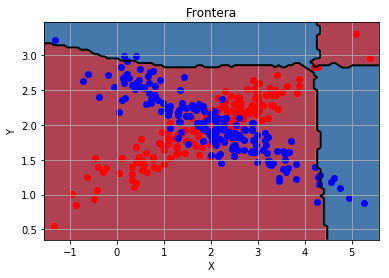

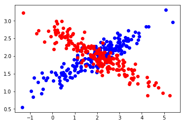

```python
%matplotlib inline
from Datos import Datos
import EstrategiaParticionado
import Clasificador
import numpy as np
from plotModel import plotModel
import matplotlib.pyplot as plt

data = 'ConjuntosDatos/example1.data'
dataset=Datos(data)
estrategia= EstrategiaParticionado.ValidacionCruzada(10)
clasificador=Clasificador.ClasificadorVecinosProximos(11,True)
errores=clasificador.validacion(estrategia,dataset,clasificador,laplace=1, seed=None)
print("Probabilidad de error: ",errores)
media = np.mean(errores)
d_tipica = np.std(np.transpose(np.array(errores)), axis=0)
print("Promedio de error: ", media)
print("Desviacion Tipica: ", d_tipica)

#plot
ii=estrategia.listaPartic[-1].indicesTrain
plotModel(dataset.datos[ii,0],dataset.datos[ii,1],dataset.datos[ii,-1]!=0,clasificador,"Frontera",dataset.nominalAtributos,dataset.diccionarios, dataset.extraeDatos(estrategia.listaPartic[-1].indicesTrain))
plt.figure()
plt.plot(dataset.datos[dataset.datos[:,-1] == 0,0], dataset.datos[dataset.datos[:,-1] == 0,1], 'bo')
plt.plot(dataset.datos[dataset.datos[:,-1] == 1,0], dataset.datos[dataset.datos[:,-1] == 1,1], 'ro')
plt.show()
```

Tras ejecutar el plot podemos observar la nube de puntos en la segunda imagen y las fronteras de esta en la primera imagen. La nube de puntos parece bastante razonable, parecida a la del enunciado con puntos a lo largo de las diagonales con puntos de cada clase cada diagonal, pero en cambio las fronteras están desplazadas hacia la derecha y hacia arriba. Esto no sabemos porque sucede ya que tiene la forma que debería pero en otra posición.

Cabe destacar que mandamos un correo al profesor para saber si nos podía orientar con este problema.

Representación Gráfica de Vecinos Próximos con el fichero "example2.data".

```
Probabilidad de error:  [0.0, 0.0, 0.0, 0.0, 0.0, 0.0, 0.0, 0.0, 0.0, 0.0]
Promedio de error:  0.0
Desviacion Tipica:  0.0
```

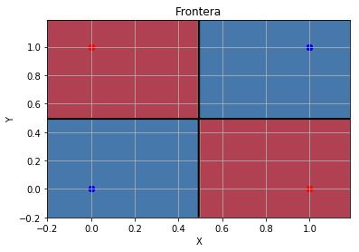

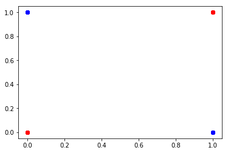

```python
%matplotlib inline
from Datos import Datos
import EstrategiaParticionado
import Clasificador
import numpy as np
from plotModel import plotModel
import matplotlib.pyplot as plt

data = 'ConjuntosDatos/example2.data'
dataset=Datos(data)
estrategia= EstrategiaParticionado.ValidacionCruzada(10)
clasificador=Clasificador.ClasificadorVecinosProximos(11,True)
errores=clasificador.validacion(estrategia,dataset,clasificador,laplace=1, seed=None)
print("Probabilidad de error: ",errores)
media = np.mean(errores)
d_tipica = np.std(np.transpose(np.array(errores)), axis=0)
print("Promedio de error: ", media)
print("Desviacion Tipica: ", d_tipica)

#plot
ii=estrategia.listaPartic[-1].indicesTrain
plotModel(dataset.datos[ii,0],dataset.datos[ii,1],dataset.datos[ii,-1]!=0,clasificador,"Frontera",dataset.nominalAtributos,dataset.diccionarios, dataset.extraeDatos(estrategia.listaPartic[-1].indicesTrain))
plt.figure()
plt.plot(dataset.datos[dataset.datos[:,-1] == 0,0], dataset.datos[dataset.datos[:,-1] == 0,1], 'bo')
plt.plot(dataset.datos[dataset.datos[:,-1] == 1,0], dataset.datos[dataset.datos[:,-1] == 1,1], 'ro')
plt.show()
```

Tras ejecutar el plot podemos observar la nube de puntos en la segunda imagen y las fronteras de esta en la primera imagen. Como podemos observar el fichero tiene puntos en las 4 esquinas de la gráfica solo, por eso nuestro clasificador clasificaba muy bien este archivo ya que solo había 4 posibilidades y el fichero es muy homogéneo. Las fronteras se diferencian muy bien y de forma clara.

Representación Gráfica de Vecinos Próximos con el fichero "example3.data".

```
Probabilidad de error:  [0.0, 0.05, 0.0, 0.075, 0.0, 0.0, 0.0, 0.0, 0.05, 0.025]
Promedio de error:  0.02
Desviacion Tipica:  0.0269258240357
```

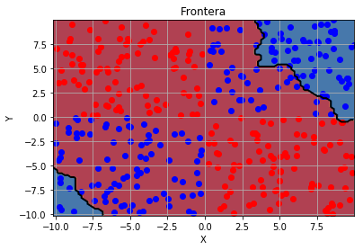

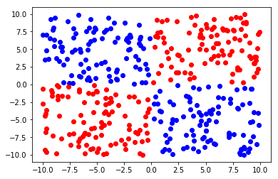

```python
%matplotlib inline
from Datos import Datos
import EstrategiaParticionado
import Clasificador
import numpy as np
from plotModel import plotModel
import matplotlib.pyplot as plt

data = 'ConjuntosDatos/example3.data'
dataset=Datos(data)
estrategia= EstrategiaParticionado.ValidacionCruzada(10)
clasificador=Clasificador.ClasificadorVecinosProximos(11,True)
errores=clasificador.validacion(estrategia,dataset,clasificador,laplace=1, seed=None)
print("Probabilidad de error: ",errores)
media = np.mean(errores)
d_tipica = np.std(np.transpose(np.array(errores)), axis=0)
print("Promedio de error: ", media)
print("Desviacion Tipica: ", d_tipica)

#plot
ii=estrategia.listaPartic[-1].indicesTrain
plotModel(dataset.datos[ii,0],dataset.datos[ii,1],dataset.datos[ii,-1]!=0,clasificador,"Frontera",dataset.nominalAtributos,dataset.diccionarios, dataset.extraeDatos(estrategia.listaPartic[-1].indicesTrain))
plt.figure()
plt.plot(dataset.datos[dataset.datos[:,-1] == 0,0], dataset.datos[dataset.datos[:,-1] == 0,1], 'bo')
plt.plot(dataset.datos[dataset.datos[:,-1] == 1,0], dataset.datos[dataset.datos[:,-1] == 1,1], 'ro')
plt.show()
```

Tras ejecutar el plot podemos observar la nube de puntos en la segunda imagen y las fronteras de esta en la primera imagen. Podemos observar en la imagen de nube de puntos como el fichero solo se compone de puntos de clase 1 arriba a la izquiera y abajo a la derecha y viceversa en caso de los puntos de clase 2 y esto es correcto, en cambio, las fronteras como pasaba con el "example1.data" no se pintan del todo bien ya que deberian ser 4 cuadrados bien definidos como se aprecia en la nube de puntos pero no lo son.

Representación Gráfica de Vecinos Próximos con el fichero "example4.data".

```
Probabilidad de error:  [0.0, 0.0, 0.0, 0.0, 0.0, 0.0, 0.0, 0.0, 0.0, 0.0]
Promedio de error:  0.0
Desviacion Tipica:  0.0
```

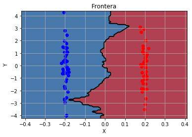

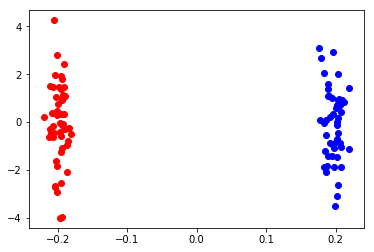

```python
%matplotlib inline
from Datos import Datos
import EstrategiaParticionado
import Clasificador
import numpy as np
from plotModel import plotModel
import matplotlib.pyplot as plt

data = 'ConjuntosDatos/example4.data'
dataset=Datos(data)
estrategia= EstrategiaParticionado.ValidacionCruzada(10)
clasificador=Clasificador.ClasificadorVecinosProximos(11,True)
errores=clasificador.validacion(estrategia,dataset,clasificador,laplace=1, seed=None)
print("Probabilidad de error: ",errores)
media = np.mean(errores)
d_tipica = np.std(np.transpose(np.array(errores)), axis=0)
print("Promedio de error: ", media)
print("Desviacion Tipica: ", d_tipica)

#plot
ii=estrategia.listaPartic[-1].indicesTrain
plotModel(dataset.datos[ii,0],dataset.datos[ii,1],dataset.datos[ii,-1]!=0,clasificador,"Frontera",dataset.nominalAtributos,dataset.diccionarios, dataset.extraeDatos(estrategia.listaPartic[-1].indicesTrain))
plt.figure()
plt.plot(dataset.datos[dataset.datos[:,-1] == 0,0], dataset.datos[dataset.datos[:,-1] == 0,1], 'bo')
plt.plot(dataset.datos[dataset.datos[:,-1] == 1,0], dataset.datos[dataset.datos[:,-1] == 1,1], 'ro')
plt.show()
```

Tras ejecutar el plot podemos observar la nube de puntos en la segunda imagen y las fronteras de esta en la primera imagen. La nube de puntos nos muestra que el fichero tiene puntos a lo largo del eje y en -0.2 de clase 1 y en 0.2 de clase 2, es por eso que nuestro clasificador clasificaba muy bien este fichero ya que era muy homogeneo. Podemos observar que las fronteras se diferencian bien unas de otras y solo surgen picos dependiendo de la densidad de puntos en un sitio concreto.

### 3.3.2 Representación Gráfica de Regresión Logística

Representación Gráfica de Regresión Logística con el fichero "example1.data".

```
Probabilidad de error:  [0.45, 0.575, 0.525, 0.55, 0.45, 0.3, 0.625, 0.55, 0.625, 0.5]
Promedio de error:  0.515
Desviacion Tipica:  0.0923309265631
```

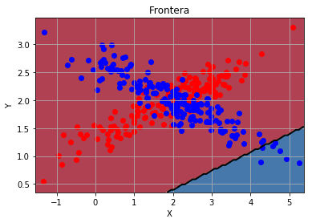

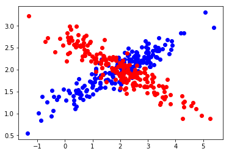

```python
%matplotlib inline
from Datos import Datos
import EstrategiaParticionado
import Clasificador
import numpy as np
from plotModel import plotModel
import matplotlib.pyplot as plt

data = 'ConjuntosDatos/example1.data'
dataset=Datos(data)
estrategia= EstrategiaParticionado.ValidacionCruzada(10)
clasificador=Clasificador.ClasificadorRegresionLogistica(100)
errores=clasificador.validacion(estrategia,dataset,clasificador,laplace=1, seed=None)
print("Probabilidad de error: ",errores)
media = np.mean(errores)
d_tipica = np.std(np.transpose(np.array(errores)), axis=0)
print("Promedio de error: ", media)
print("Desviacion Tipica: ", d_tipica)

#plot
ii=estrategia.listaPartic[-1].indicesTrain
plotModel(dataset.datos[ii,0],dataset.datos[ii,1],dataset.datos[ii,-1]!=0,clasificador,"Frontera",dataset.nominalAtributos,dataset.diccionarios, dataset.extraeDatos(estrategia.listaPartic[-1].indicesTrain))
plt.figure()
plt.plot(dataset.datos[dataset.datos[:,-1] == 0,0], dataset.datos[dataset.datos[:,-1] == 0,1], 'bo')
plt.plot(dataset.datos[dataset.datos[:,-1] == 1,0], dataset.datos[dataset.datos[:,-1] == 1,1], 'ro')
plt.show()
```

Tras ejecutar el plot podemos observar la nube de puntos en la segunda imagen y las fronteras de esta en la primera imagen. La nube de puntos parece bastante razonable, parecida a la del enunciado con puntos a lo largo de las diagonales con puntos de cada clase cada diagonal, las frontera que marca la clase 1 es mucho mayor que la de clase 2 ya que quizás haya muchos más puntos de clase 1 o porque tienen mayor peso.

Representación Gráfica de Regresión Logística con el fichero "example2.data".

```
Probabilidad de error:  [0.45, 0.575, 0.4, 0.525, 0.65, 0.425, 0.475, 0.5, 0.575, 0.3]
Promedio de error:  0.4875
Desviacion Tipica:  0.095688296045
```

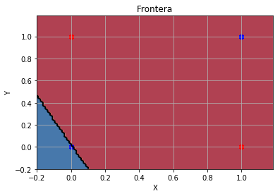

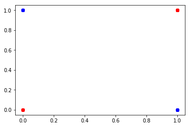

```python
%matplotlib inline
from Datos import Datos
import EstrategiaParticionado
import Clasificador
import numpy as np
from plotModel import plotModel
import matplotlib.pyplot as plt

data = 'ConjuntosDatos/example2.data'
dataset=Datos(data)
estrategia= EstrategiaParticionado.ValidacionCruzada(10)
clasificador=Clasificador.ClasificadorRegresionLogistica(100)
errores=clasificador.validacion(estrategia,dataset,clasificador,laplace=1, seed=None)
print("Probabilidad de error: ",errores)
media = np.mean(errores)
d_tipica = np.std(np.transpose(np.array(errores)), axis=0)
print("Promedio de error: ", media)
print("Desviacion Tipica: ", d_tipica)

#plot
ii=estrategia.listaPartic[-1].indicesTrain
plotModel(dataset.datos[ii,0],dataset.datos[ii,1],dataset.datos[ii,-1]!=0,clasificador,"Frontera",dataset.nominalAtributos,dataset.diccionarios, dataset.extraeDatos(estrategia.listaPartic[-1].indicesTrain))
plt.figure()
plt.plot(dataset.datos[dataset.datos[:,-1] == 0,0], dataset.datos[dataset.datos[:,-1] == 0,1], 'bo')
plt.plot(dataset.datos[dataset.datos[:,-1] == 1,0], dataset.datos[dataset.datos[:,-1] == 1,1], 'ro')
plt.show()
```

Representación Gráfica de Regresión Logística con el fichero "example3.data".

```
Probabilidad de error:  [0.75, 0.5, 0.575, 0.65, 0.65, 0.575, 0.575, 0.575, 0.45, 0.5]
Promedio de error:  0.58
Desviacion Tipica:  0.0827647267862
```

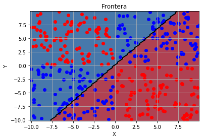

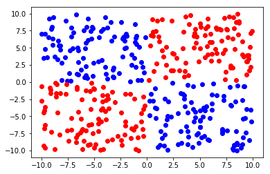

```python
%matplotlib inline
from Datos import Datos
import EstrategiaParticionado
import Clasificador
import numpy as np
from plotModel import plotModel
import matplotlib.pyplot as plt

data = 'ConjuntosDatos/example3.data'
dataset=Datos(data)
estrategia= EstrategiaParticionado.ValidacionCruzada(10)
clasificador=Clasificador.ClasificadorRegresionLogistica(100)
errores=clasificador.validacion(estrategia,dataset,clasificador,laplace=1, seed=None)
print("Probabilidad de error: ",errores)
media = np.mean(errores)
d_tipica = np.std(np.transpose(np.array(errores)), axis=0)
print("Promedio de error: ", media)
print("Desviacion Tipica: ", d_tipica)

#plot
ii=estrategia.listaPartic[-1].indicesTrain
plotModel(dataset.datos[ii,0],dataset.datos[ii,1],dataset.datos[ii,-1]!=0,clasificador,"Frontera",dataset.nominalAtributos,dataset.diccionarios, dataset.extraeDatos(estrategia.listaPartic[-1].indicesTrain))
plt.figure()
plt.plot(dataset.datos[dataset.datos[:,-1] == 0,0], dataset.datos[dataset.datos[:,-1] == 0,1], 'bo')
plt.plot(dataset.datos[dataset.datos[:,-1] == 1,0], dataset.datos[dataset.datos[:,-1] == 1,1], 'ro')
plt.show()
```

Tras ejecutar el plot podemos observar la nube de puntos en la segunda imagen y las fronteras de esta en la primera imagen. Podemos observar en la imagen de nube de puntos como el fichero solo se compone de puntos de clase 1 arriba a la izquiera y abajo a la derecha y viceversa en caso de los puntos de clase 2 y esto es correcto, en cambio la frontera es una diagonal en el diagrama, esto es debido a que hay el mismo número de puntos de clase 1 que de clase 2 y esparcidos de forma equivalente por lo que forma una diagonal.

Representación Gráfica de Regresión Logística con el fichero "example4.data".

```
Probabilidad de error:  [0.0, 0.0, 0.0, 0.0, 0.0, 0.0, 0.0, 0.0, 0.0, 0.0]
Promedio de error:  0.0
Desviacion Tipica:  0.0
```

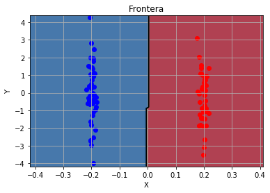

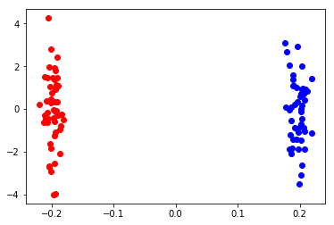

```python
%matplotlib inline
from Datos import Datos
import EstrategiaParticionado
import Clasificador
import numpy as np
from plotModel import plotModel
import matplotlib.pyplot as plt

data = 'ConjuntosDatos/example4.data'
dataset=Datos(data)
estrategia= EstrategiaParticionado.ValidacionCruzada(10)
clasificador=Clasificador.ClasificadorRegresionLogistica(100)
errores=clasificador.validacion(estrategia,dataset,clasificador,laplace=1, seed=None)
print("Probabilidad de error: ",errores)
media = np.mean(errores)
d_tipica = np.std(np.transpose(np.array(errores)), axis=0)
print("Promedio de error: ", media)
print("Desviacion Tipica: ", d_tipica)

#plot
ii=estrategia.listaPartic[-1].indicesTrain
plotModel(dataset.datos[ii,0],dataset.datos[ii,1],dataset.datos[ii,-1]!=0,clasificador,"Frontera",dataset.nominalAtributos,dataset.diccionarios, dataset.extraeDatos(estrategia.listaPartic[-1].indicesTrain))
plt.figure()
plt.plot(dataset.datos[dataset.datos[:,-1] == 0,0], dataset.datos[dataset.datos[:,-1] == 0,1], 'bo')
plt.plot(dataset.datos[dataset.datos[:,-1] == 1,0], dataset.datos[dataset.datos[:,-1] == 1,1], 'ro')
plt.show()
```

Tras ejecutar el plot podemos observar la nube de puntos en la segunda imagen y las fronteras de esta en la primera imagen. La nube de puntos nos muestra que el fichero tiene puntos a lo largo del eje y en -0.2 de clase 1 y en 0.2 de clase 2, es por eso que nuestro clasificador clasificaba muy bien este fichero ya que era muy homogeneo. Podemos observar que las fronteras se diferencian bien entre las dos clases.